# Reproducible Research: Peer Assessment 1

## Loading and preprocessing the data

Reading the data from the file ‘activity.csv’ that containing 3 columns:

- Steps: Number of steps taking in a 5-minute interval
- Date: The date on which the measurement was taken
- Interval: Identifier for the 5-minute interval in which measurement was taken

```r
activity <- read.csv("activity.csv")
```

## What is mean total number of steps taken per day?

Analysing the steps taken each day, omitting missing values. The values are summarized in a histogram. Then the mean and median steps taken per day are calculated

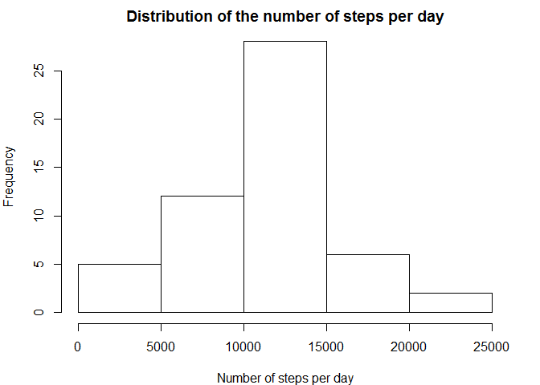

```r
tab1 <- na.omit(as.data.frame(tapply(activity$steps,as.factor(activity$date), sum)))

par(mar=c(4,4,2,2), cex=1)

hist(tab1[,1], xlab="Number of steps per day",
     main="Distribution of the number of steps per day")
```

```r
summary = summary(tab1)
c(summary[4],summary[3])
```

```
## [1] "Mean   :10766  " "Median :10765  "
```

## What is the average daily activity pattern?

Analysing a daily activity pattern: the average number of steps per 5-minutes intervals, averaged over all days, is calulated, again omitting missing data.

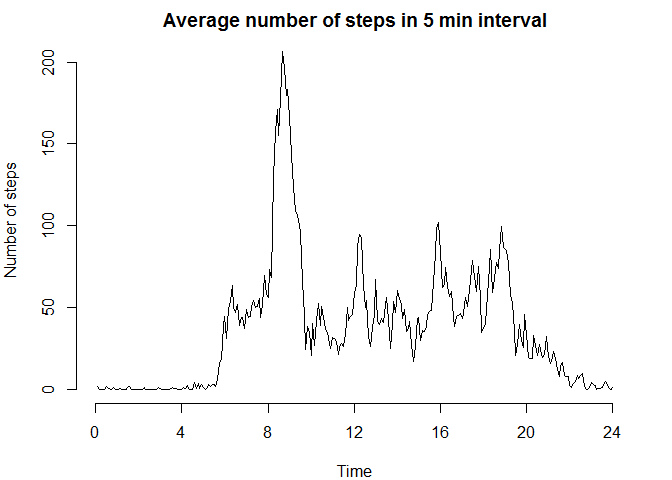

```r
activityVals <- subset(activity,!is.na(activity$steps))
tab2 <- tapply(activityVals$steps,as.factor(activityVals$interval), mean)

par(mar=c(4,4,2,2), cex=1)

plot(tab2, xlab="Time", axes=FALSE, ylab="Number of steps",
     main="Average number of steps in 5 min interval",
     type="l")
axis(2)
axis(1, at=c(0,48,96,144,192,240,288), labels=c("0","4","8","12","16","20","24"))
```

The 5-minute interval with the highest number of average steps is calulated:

```r
rownames(tab2)[match(max(tab2),tab2)]
```

```
## [1] "835"
```

## Imputing missing values

- Calculating the number of missing values:

```r
sum(is.na(activity$steps))
```

```
## [1] 2304
```

- Then the missing values are filled in by taking the average number of steps of the corresponding 5 minute interval (rounded to integer values) calculated in part 2.

```r
library(stringr)

fill <- function(row) {

  if(is.na(row[1]))
    row[1] <- round(tab2[as.character(as.integer(row[3]))])

  return(row)
}
activityFilled <- as.data.frame(aperm(apply(activity,1,fill),perm=c(2,1)))
```

- Analysing the steps taken each day and summarize the values in a histogram (same as for the original dataset) Then the mean and median steps taken per day are calculated

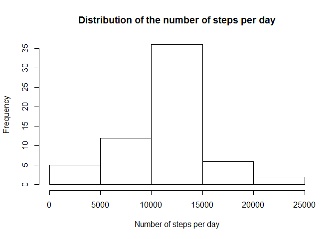

```r
tab3 <- tapply(as.integer(as.character(activityFilled$steps)),
               as.factor(activityFilled$date), sum)

hist(tab3, xlab="Number of steps per day",
     main="Distribution of the number of steps per day")
```

```r
summary = summary(tab3)
c(summary[4],summary[3])
```

```
##   Mean Median
##  10770  10760
```

## Are there differences in activity patterns between weekdays and weekends?

```r
Sys.setlocale("LC_TIME", "English")
```

```
## [1] "English_United States.1252"
```

```r
activityFilled$wDay <-
  as.factor(ifelse((weekdays(as.Date(activityFilled[[2]])) == "Sunday" |
                    weekdays(as.Date(activityFilled[[2]])) == "Saturday"),
                   "weekend", "workday"))

activityWE <- subset(activityFilled,(activityFilled$wDay=="weekend"))
activityWD <- subset(activityFilled,(activityFilled$wDay=="workday"))
```

Now we calculate the 5 minute intervals averaged over workdays and weekends separately and plot it:

[figure not shown]

```r
tabWD <- data.frame(matrix(NA, nrow = 288, ncol = 0))
tabWD$interval <- as.integer(rownames(tab2))
tabWD$steps <- tapply(as.integer(as.character(activityWD$steps)),
                as.factor(activityWD$interval), mean)
tabWD$day <- as.factor(rep("Workday", 288))

tabWE <- data.frame(matrix(NA, nrow = 288, ncol = 0))
tabWE$interval <- as.integer(rownames(tab2))
tabWE$steps <- tapply(as.integer(as.character(activityWE$steps)),
                as.factor(activityWE$interval), mean)
tabWE$day <- as.factor(rep("Weekday", 288))

tab4 = rbind(tabWE, tabWD)

library(lattice)
xyplot(steps~interval|day, data = tab4, type="l",
   main="Average number of steps per 5 minute interval",
   xlab="Interval",
   ylab="Number of steps",
   layout=c(1,2))
```